# Excess mortality

Final outputs for paper and appendix

# Result files

## Primary results from age adjusted models

```r
results_month <- merge_mort(bind_rows(
  read_rds("data/outputs_2021-11-23/Sweden_results_month.Rds"),
  read_rds("data/outputs_2021-11-24/Spain_results_month.Rds"),
  read_rds("data/outputs_2021-11-23/Switzerland_results_month.Rds")
)) %>%
  filter(Model == "Age Serfling (Stan, NB)") %>%
  mutate(Date = anytime::anydate(paste0(Year, "-", Month))) %>%
  arrange(Country, Year, Month) %>%
  relocate(c(n_eff, Rhat), .after = last_col()) %>%
  mutate(across(pred_total_deaths:excess_month_upper, round)) %>%
  relocate(Model, Pandemic, Country, Year, Month, Date)

results_year <- merge_mort(bind_rows(
  read_rds("data/outputs_2021-11-23/Sweden_results_year.Rds"),
  read_rds("data/outputs_2021-11-24/Spain_results_year.Rds"),
  read_rds("data/outputs_2021-11-23/Switzerland_results_year.Rds")
)) %>%
  filter(Model == "Age Serfling (Stan, NB)") %>%
  arrange(Country, Year) %>%
  mutate(across(yearly_pred_total_deaths:yearly_excess_total_deaths_upper, round)) %>%
  relocate(Model, Pandemic)

results_age <- merge_mort(bind_rows(
  read_rds("data/outputs_2021-11-23/Sweden_results_age.Rds"),
  read_rds("data/outputs_2021-11-24/Spain_results_age.Rds"),
  read_rds("data/outputs_2021-11-23/Switzerland_results_age.Rds")
)) %>%
  filter(Model == "Age Serfling (Stan, NB)") %>%
  arrange(Country, Year) %>%
  mutate(across(pred_grouped_deaths:excess_grouped_lifelost70_upper, round)) %>%
  relocate(Model, Pandemic, Country, Year, Age_cat, Deaths)
```

## Sensitivity analysis using Bayesian NB model, unadjusted models

```r
results_year_global <- merge_mort(bind_rows(
  read_rds("data/outputs_2021-11-23/Sweden_results_year.Rds"),
  read_rds("data/outputs_2021-11-24/Spain_results_year.Rds"),
  read_rds("data/outputs_2021-11-23/Switzerland_results_year.Rds")
)) %>%
  filter(Model == "Global Serfling (Stan, NB)") %>%
  arrange(Country, Year) %>%
  mutate(across(yearly_pred_total_deaths:yearly_excess_total_deaths_upper, round)) %>%
  relocate(Model, Pandemic)
```

## Sensitivity analysis using frequentist Poisson model, unadjusted for age

```r
results_month_boot <- read_rds("data/outputs_2021-11-18/All_results_month.Rds") %>%
  mutate(Date = anytime::anydate(paste0(Year, "-", Month))) %>%
  arrange(Country, Year, Month) %>%
  mutate(across(pred:excess_month_lower, round)) %>%
  mutate(Model = "Global Serfling (bootstrap)") %>%
  relocate(Model, Country, Year, Month, Date)
```

## Sensitivity analysis using alternative longer (7 days) time window

```r
results_year_last_7_notrim <- merge_mort(bind_rows(
  read_rds("data/outputs_2021-12-01/Sweden_results_year_last_7_notrim.Rds"),
  read_rds("data/outputs_2021-12-01/Spain_results_year_last_7_notrim.Rds"),
  read_rds("data/outputs_2021-12-01/Switzerland_results_year_last_7_notrim.Rds")
)) %>%
  filter(Model == "Age Serfling (Stan, NB, last 7 no trim)") %>%
  arrange(Country, Year) %>%
  mutate(across(yearly_pred_total_deaths:yearly_excess_total_deaths_upper, round)) %>%
  relocate(Model, Pandemic)
```

## Sensitivity analysis using alternative time window & min/max selection

```r
results_year_last_7_trim <- merge_mort(bind_rows(
  read_rds("data/outputs_2021-11-23/Sweden_results_year_last_7_trim.Rds"),
  read_rds("data/outputs_2021-11-24/Spain_results_year_last_7_trim.Rds"),
  read_rds("data/outputs_2021-11-23/Switzerland_results_year_last_7_trim.Rds")
)) %>%
  filter(Model == "Age Serfling (Stan, NB, last 7)") %>%
  arrange(Country, Year) %>%
  mutate(across(yearly_pred_total_deaths:yearly_excess_total_deaths_upper, round)) %>%
  relocate(Model, Pandemic)
```

## Sensitivity analysis for including effects of pandemics

```r
results_month_pand <- merge_mort(bind_rows(
  read_rds("data/outputs_2021-11-23/Sweden_results_month_pand.Rds"),
  read_rds("data/outputs_2021-11-24/Spain_results_month_pand.Rds"),
  read_rds("data/outputs_2021-11-23/Switzerland_results_month_pand.Rds")
)) %>%
  filter(Model == "Age Serfling (Stan, NB, pandemic)") %>%
  mutate(Date = anytime::anydate(paste0(Year, "-", Month))) %>%
  relocate(c(n_eff, Rhat), .after = last_col()) %>%
  arrange(Country, Year, Month) %>%
  mutate(across(pred_total_deaths:excess_month_upper, round)) %>%
  relocate(Model, Pandemic, Country, Year, Month, Date)
```

## Population

```r
pops <- read_rds("data/deaths_monthly.Rds") %>%
  filter(Month == 1) %>%
  select(Year, Country, Population_obs) %>%
  rename(Population = Population_obs)
```

## COVID-19 cases

```r
covid_cases_deaths_jh <- read_rds("data/covid_cases_deaths_jh.Rds")
```

## Yearly deaths by age

```r
deaths_yearly_age_sex <- read_rds("data/deaths_yearly_age_sex.Rds")
```

# Paper outputs

## Table 1

| Country | Population | All-cause deaths Count | All-cause deaths Expected$^*$ | COVID-19 deaths Count$^†$ |
| --- | --- | --- | --- | --- |
| **1890** |  |  |  |  |
| Switzerland | 2,949,868 | 61,805 | 55,700 to 61,100 | – |
| Sweden | 4,775,819 | 81,824 | 69,300 to 77,000 | – |
| **1918** |  |  |  |  |
| Switzerland | 3,878,360 | 75,034 | 47,600 to 53,100 | – |
| Sweden | 5,802,022 | 104,591 | 73,500 to 84,000 | – |
| Spain | 21,300,235 | 695,758 | 429,700 to 480,000 | – |
| **1957** |  |  |  |  |
| Switzerland | 5,097,745 | 51,066 | 49,300 to 54,700 | – |
| Sweden | 7,341,017 | 73,132 | 67,800 to 73,000 | – |
| Spain | 29,445,865 | 293,502 | 264,700 to 296,200 | – |
| **2020** |  |  |  |  |
| Switzerland | 8,605,965 | 76,195 | 64,700 to 70,900 | 7,873 |
| Sweden | 10,327,496 | 97,870 | 86,900 to 93,700 | 8,727 |
| Spain | 47,332,613 | 492,930 | 400,500 to 441,000 | 50,837 |
| **2021$^‡$** |  |  |  |  |
| Switzerland | 8,670,302 | 34,619 | 33,700 to 37,700 | 2,900 |
| Sweden | 10,379,295 | – | – | 5,903 |
| Spain | 47,394,223 | 234,994 | 210,300 to 238,400 | 30,046 |

* Model-predicted number of all-cause deaths from the five preceding years (95% credible interval, rounded to the next 100).  
† Data from Johns Hopkins Coronavirus Resource Center  
‡ First six months of the year only included in the analyses. No age specific data available for this time period for Sweden.

## Table 2

Three measures of excess (all from main, age adjusted NB model with observed population counts) and years life lost.

| Country | Absolute excess deaths Count | Absolute excess deaths 95% CrI | Absolute excess deaths per population$^*$ Per 100,000 | Absolute excess deaths per population$^*$ 95% CrI | Relative excess deaths$^†$ % | Relative excess deaths$^†$ 95% CrI | Life years lost until 70$^‡$ Thousands | Life years lost until 70$^‡$ 95% CrI |
| --- | --- | --- | --- | --- | --- | --- | --- | --- |
| **1890** |  |  |  |  |  |  |  |  |
| Switzerland | 3,456 | (703 to 6,118) | 115 | (25 to 205) | 6.0% | (1.2% to 11.0%) | 50 | (-40 to 135) |
| Sweden | 8,810 | (4,871 to 12,573) | 185 | (100 to 265) | 12.1% | (6.3% to 18.2%) | 235 | (110 to 360) |
| **1918** |  |  |  |  |  |  |  |  |
| Switzerland | 24,730 | (21,925 to 27,453) | 640 | (565 to 710) | 49.3% | (41.3% to 57.7%) | 900 | (835 to 965) |
| Sweden | 25,937 | (20,597 to 31,087) | 445 | (355 to 535) | 33.1% | (24.5% to 42.3%) | 1,070 | (945 to 1,190) |
| Spain | 241,661 | (215,791 to 266,103) | 1,135 | (1,015 to 1,250) | 53.3% | (45.0% to 61.9%) | 10,050 | (9,130 to 10,925) |
| **1957** |  |  |  |  |  |  |  |  |
| Switzerland | -922 | (-3,679 to 1,804) | -20 | (-70 to 35) | -1.7% | (-6.7% to 3.7%) | -20 | (-50 to 5) |
| Sweden | 2,760 | (101 to 5,338) | 40 | (0 to 75) | 4.0% | (0.1% to 7.9%) | 10 | (-15 to 30) |
| Spain | 13,227 | (-2,659 to 28,783) | 45 | (-10 to 100) | 4.8% | (-0.9% to 10.9%) | -105 | (-385 to 170) |
| **2020** |  |  |  |  |  |  |  |  |
| Switzerland | 8,429 | (5,253 to 11,449) | 100 | (60 to 135) | 12.5% | (7.4% to 17.7%)$^§$ | 5 | (-5 to 15) |
| Sweden | 7,656 | (4,199 to 10,984) | 75 | (40 to 105) | 8.5% | (4.5% to 12.6%)$^§$ | 5 | (-5 to 15) |
| Spain | 72,328 | (51,942 to 92,409) | 155 | (110 to 195) | 17.3% | (11.8% to 23.1%)$^§$ | 90 | (40 to 145) |
| **2021** |  |  |  |  |  |  |  |  |
| Switzerland | -1,002 | (-3,087 to 957) | -10 | (-35 to 10) | -2.7% | (-8.2% to 2.8%) | -5 | (-10 to 0) |
| Spain | 10,867 | (-3,423 to 24,715) | 25 | (-5 to 50) | 5.0% | (-1.4% to 11.8%) | 5 | (-30 to 40) |

* Absolute number of excess deaths scaled by country population.  
† Absolute number of excess deaths scaled by the number of expected deaths.  
‡ Sum of life years lost until the age of 70 in thousands.  
<sup>§</sup> Based on 8,000 posterior samples, the probability that the relative excess deaths in 2020 is larger than in 1957 is 100%, 94.3% and 99.9% in Switzerland, Sweden and Spain, respectively.

## Figure 1

Yearly excess per population.

**Note:** *the scales of Y axes vary by country!*

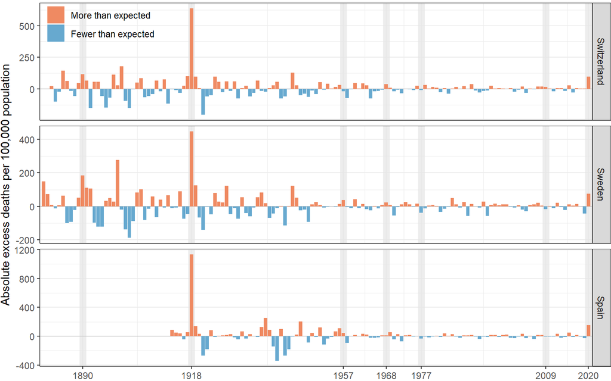

## Figure 2

Zooming to pandemics to explore absolute excess with CrI.

FIXME: needs legend!

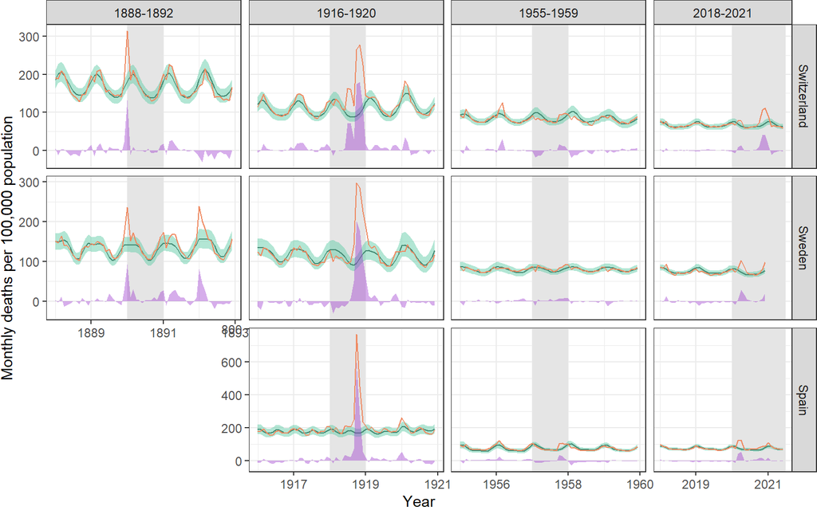

## Figure 3

Age differences across major pandemics (per population).

**Note:** *Excludes category `[90,120]` in pandemic years `1890` & `1918` due to small number of deaths in these age groups resulting in very large CrI.*

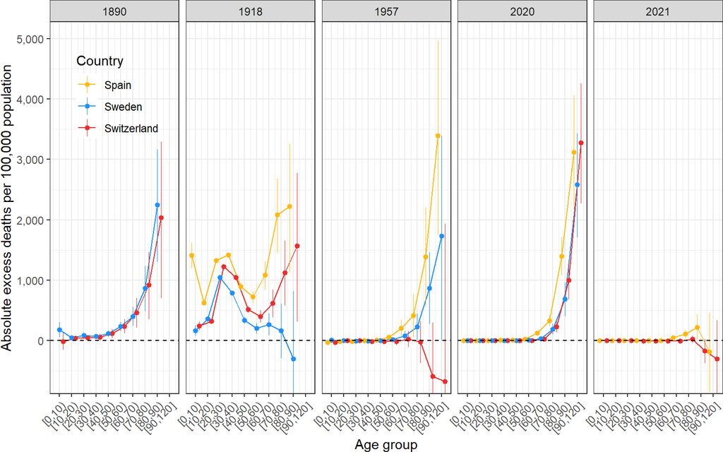

# Appendix

## Table S1

Comparing main estimates (`Age Serfling (Stan, NB)`) of excess from alternative methods:

- `Global Serfling (bootstrap)`
- `Global Serfling (Stan, NB)`
- `Age Serfling with alternative 7 day time window and min/max trim (Stan, NB)`
- `Age Serfling with alternative 7 day time window and no trim (Stan, NB)`

```r
pandemic_years <- c(1890, 1918, 1957, 2020, 2021)

table_s1 <-

  bind_rows(

    # baseline, ie. reported in paper `Age Serfling (Stan, NB)`
    results_year  %>%
      mutate(Model = "m0") %>%
      select(Model, Country, Year,
             starts_with("yearly_excess_total_deaths")),

    # Global Serfling (bootstrap)
    # simply summed from monthly values to obtain year
    # !without CI for yearly!
    results_month_boot %>%
      mutate(excess = Deaths - pred) %>%
      group_by(Model, Country, Year) %>%
      summarise(yearly_excess_total_deaths = sum(excess)) %>%
      ungroup() %>%
      mutate(Model = "m1"),

    # Global Serfling (Stan, NB) without age
    results_year_global  %>%
      mutate(Model = "m2") %>%
      select(Model, Country, Year,
             starts_with("yearly_excess_total_deaths")),

    # Age Serfling with alternative time window & min/max trim (Stan, NB)
    results_year_last_7_notrim  %>%
      mutate(Model = "m3") %>%
      select(Model, Country, Year,
             starts_with("yearly_excess_total_deaths")),

    # Age Serfling with alternative time window (Stan, NB)
    results_year_last_7_trim  %>%
      mutate(Model = "m4") %>%
      select(Model, Country, Year,
             starts_with("yearly_excess_total_deaths"))

  ) %>%
  filter(Year %in% c(pandemic_years, pandemic_years - 1, pandemic_years + 1)) %>%
  arrange(desc(Country), Year, Model) %>%
  pivot_wider(names_from = Model,
              values_from = starts_with("yearly_excess"),
              names_sort = FALSE) %>%
  relocate(Country, Year,
           yearly_excess_total_deaths_m0,
           yearly_excess_total_deaths_lower_m0,
           yearly_excess_total_deaths_upper_m0,
           yearly_excess_total_deaths_m1,
           yearly_excess_total_deaths_lower_m1,
           yearly_excess_total_deaths_upper_m1,
           yearly_excess_total_deaths_m2,
           yearly_excess_total_deaths_lower_m2,
           yearly_excess_total_deaths_upper_m2,
           yearly_excess_total_deaths_m3,
           yearly_excess_total_deaths_lower_m3,
           yearly_excess_total_deaths_upper_m3,
           yearly_excess_total_deaths_m4,
           yearly_excess_total_deaths_lower_m4,
           yearly_excess_total_deaths_upper_m4
  ) %>%
  select(-yearly_excess_total_deaths_lower_m1, -yearly_excess_total_deaths_upper_m1) %>%

  mutate(
    yearly_excess_total_deaths_m0 = number(yearly_excess_total_deaths_m0,
                                           accuracy = 5L, big.mark = ","),
    yearly_excess_total_deaths_m1 = number(yearly_excess_total_deaths_m1,
                                           accuracy = 5L, big.mark = ","),
    yearly_excess_total_deaths_m2 = number(yearly_excess_total_deaths_m2,
                                           accuracy = 5L, big.mark = ","),
    yearly_excess_total_deaths_m3 = number(yearly_excess_total_deaths_m3,
                                           accuracy = 5L, big.mark = ","),
    yearly_excess_total_deaths_m4 = number(yearly_excess_total_deaths_m4,
                                           accuracy = 5L, big.mark = ",")
  ) %>%

  mutate(
    yearly_excess_total_deaths_m0_cri = str_c("(",
                                              number(yearly_excess_total_deaths_lower_m0,
                                                     accuracy = 5L, big.mark = ","),
                                              " to ",
                                              number(yearly_excess_total_deaths_upper_m0,
                                                     accuracy = 5L, big.mark = ","),
                                              ")")
  ) %>%
  relocate(yearly_excess_total_deaths_m0_cri,
           .after = yearly_excess_total_deaths_m0) %>%
  select(-yearly_excess_total_deaths_lower_m0,
         -yearly_excess_total_deaths_upper_m0) %>%

  mutate(
    yearly_excess_total_deaths_m2_cri = str_c("(",
                                              number(yearly_excess_total_deaths_lower_m2,
                                                     accuracy = 5L, big.mark = ","),
                                              " to ",
                                              number(yearly_excess_total_deaths_upper_m2,
                                                     accuracy = 5L, big.mark = ","),
                                              ")")
  ) %>%
  relocate(yearly_excess_total_deaths_m2_cri,
           .after = yearly_excess_total_deaths_m2) %>%
  select(-yearly_excess_total_deaths_lower_m2,
         -yearly_excess_total_deaths_upper_m2) %>%

  mutate(
    yearly_excess_total_deaths_m3_cri = str_c("(",
                                              number(yearly_excess_total_deaths_lower_m3,
                                                     accuracy = 5L, big.mark = ","),
                                              " to ",
                                              number(yearly_excess_total_deaths_upper_m3,
                                                     accuracy = 5L, big.mark = ","),
                                              ")")
  ) %>%
  relocate(yearly_excess_total_deaths_m3_cri, .after = yearly_excess_total_deaths_m3) %>%
  select(-yearly_excess_total_deaths_lower_m3, -yearly_excess_total_deaths_upper_m3) %>%

  mutate(
    yearly_excess_total_deaths_m4_cri = str_c("(",
                                              number(yearly_excess_total_deaths_lower_m4,
                                                     accuracy = 5L, big.mark = ","),
                                              " to ",
                                              number(yearly_excess_total_deaths_upper_m4,
                                                     accuracy = 5L, big.mark = ","),
                                              ")")
  ) %>%
  relocate(yearly_excess_total_deaths_m4_cri, .after = yearly_excess_total_deaths_m4) %>%
  select(-yearly_excess_total_deaths_lower_m4, -yearly_excess_total_deaths_upper_m4) %>%

  mutate(across(yearly_excess_total_deaths_m0:yearly_excess_total_deaths_m4_cri,
                ~replace(., is.na(.), "--")))

openxlsx::write.xlsx(table_s1, "paper/Table_S1.xlsx",
                     row.names = FALSE, overwrite = TRUE)
```

| Country, Year | Baseline Excess | Baseline 95% CrI | Sensitivity 1$^*$ Excess | Sensitivity 2$^†$ Excess | Sensitivity 2$^†$ 95% CrI | Sensitivity 3$^‡$ Excess | Sensitivity 3$^‡$ 95% CrI | Sensitivity 4$^§$ Excess | Sensitivity 4$^§$ 95% CrI |
| --- | --- | --- | --- | --- | --- | --- | --- | --- | --- |
| **Switzerland** |  |  |  |  |  |  |  |  |  |
| 1889 | 1,380 | (-1,550 to 4,255) | 1,100 | 1,300 | (-1,650 to 4,130) | 1,680 | (-865 to 4,190) | -410 | (-3,405 to 2,510) |
| 1890 | 3,455 | (705 to 6,120) | 3,380 | 3,360 | (605 to 6,015) | 2,395 | (-310 to 5,020) | 1,790 | (-1,110 to 4,565) |
| 1891 | 1,920 | (-1,265 to 5,010) | 1,975 | 1,585 | (-1,605 to 4,520) | 1,950 | (-825 to 4,670) | 990 | (-2,140 to 4,045) |
| 1917 | 3,810 | (1,155 to 6,395) | 3,630 | 3,855 | (1,175 to 6,505) | 4,035 | (1,240 to 6,670) | 1,905 | (-925 to 4,630) |
| 1918 | 24,730 | (21,925 to 27,455) | 24,460 | 24,625 | (21,690 to 27,465) | 25,725 | (22,845 to 28,480) | 23,705 | (20,540 to 26,705) |
| 1919 | 3,730 | (510 to 6,835) | 3,820 | 3,700 | (515 to 6,790) | 4,600 | (1,895 to 7,275) | 3,455 | (200 to 6,540) |
| 1956 | 1,535 | (-775 to 3,750) | 1,555 | 1,470 | (-865 to 3,725) | 1,695 | (-505 to 3,905) | 1,555 | (-630 to 3,710) |
| 1957 | -920 | (-3,680 to 1,805) | -1,200 | -1,035 | (-3,835 to 1,675) | -180 | (-2,650 to 2,250) | -25 | (-2,440 to 2,295) |
| 1958 | -3,705 | (-6,950 to -605) | -3,360 | -3,190 | (-6,315 to -185) | -2,980 | (-5,535 to -475) | -2,760 | (-5,095 to -380) |
| 2019 | 165 | (-3,210 to 3,400) | 280 | 320 | (-2,950 to 3,460) | 395 | (-2,200 to 2,895) | 600 | (-1,865 to 2,975) |
| 2020 | 8,430 | (5,255 to 11,450) | 8,810 | 8,685 | (5,575 to 11,675) | 8,105 | (5,505 to 10,630) | 7,360 | (4,395 to 10,240) |
| 2021 | -1,000 | (-3,085 to 955) | -845 | -715 | (-2,735 to 1,220) | -795 | (-2,715 to 1,010) | -925 | (-3,280 to 1,375) |
| **Sweden** |  |  |  |  |  |  |  |  |  |
| 1889 | 2,495 | (-1,400 to 6,155) | 2,785 | 2,540 | (-1,280 to 6,290) | 290 | (-3,385 to 3,790) | -1,125 | (-5,425 to 2,960) |
| 1890 | 8,810 | (4,870 to 12,575) | 8,720 | 8,525 | (4,475 to 12,495) | 7,380 | (3,750 to 10,945) | 7,060 | (2,930 to 11,055) |
| 1891 | 5,295 | (800 to 9,480) | 6,365 | 5,570 | (1,045 to 9,800) | 6,515 | (2,655 to 10,245) | 5,875 | (1,405 to 10,255) |
| 1917 | -2,640 | (-7,970 to 2,330) | -2,980 | -2,865 | (-8,140 to 2,105) | -2,945 | (-7,240 to 1,245) | -645 | (-4,165 to 2,725) |
| 1918 | 25,935 | (20,595 to 31,085) | 25,505 | 25,695 | (20,310 to 30,885) | 25,735 | (21,420 to 29,845) | 27,700 | (23,945 to 31,250) |
| 1919 | 7,245 | (1,180 to 12,965) | 8,260 | 7,140 | (1,020 to 12,835) | 5,875 | (1,265 to 10,350) | 7,395 | (3,625 to 11,080) |
| 1956 | 1,080 | (-2,395 to 4,445) | 1,585 | 1,450 | (-2,085 to 4,910) | 1,050 | (-1,825 to 3,820) | 880 | (-2,410 to 4,065) |
| 1957 | 2,760 | (100 to 5,340) | 3,040 | 2,990 | (395 to 5,515) | 3,325 | (410 to 6,220) | 3,135 | (-470 to 6,575) |
| 1958 | -360 | (-3,505 to 2,720) | 1,040 | 620 | (-2,465 to 3,605) | -315 | (-3,565 to 2,800) | -800 | (-4,875 to 3,060) |
| 2019 | -4,365 | (-8,015 to -795) | -4,390 | -4,255 | (-7,810 to -730) | -3,350 | (-6,330 to -345) | -4,380 | (-7,125 to -1,695) |
| 2020 | 7,655 | (4,200 to 10,985) | 8,465 | 8,405 | (4,960 to 11,690) | 6,760 | (3,635 to 9,910) | 2,600 | (-690 to 5,750) |
| 2021 | – | – | 1,700 | 750 | (-1,845 to 3,160) | – | – | – | – |
| **Spain** |  |  |  |  |  |  |  |  |  |
| 1917 | 11,645 | (-13,875 to 36,180) | 12,155 | 12,020 | (-13,400 to 36,025) | 22,060 | (-900 to 44,430) | 20,950 | (1,005 to 40,565) |
| 1918 | 241,660 | (215,790 to 266,105) | 239,680 | 239,495 | (214,035 to 264,175) | 243,240 | (218,610 to 266,700) | 241,660 | (215,790 to 266,105) |
| 1919 | 28,835 | (1,100 to 55,560) | 23,340 | 22,835 | (-4,940 to 49,265) | 24,670 | (-165 to 48,125) | 45,235 | (21,520 to 67,910) |
| 1956 | 32,305 | (9,145 to 53,685) | 39,455 | 33,085 | (10,205 to 54,805) | 33,355 | (14,275 to 51,825) | 30,730 | (15,545 to 45,480) |
| 1957 | 13,225 | (-2,660 to 28,785) | 10,715 | 11,675 | (-4,495 to 27,310) | 28,360 | (7,820 to 48,025) | 21,360 | (4,365 to 37,570) |
| 1958 | -28,160 | (-47,480 to -9,435) | -32,630 | -28,615 | (-48,745 to -9,615) | -11,425 | (-33,630 to 9,845) | -27,265 | (-44,020 to -10,910) |
| 2019 | -13,370 | (-34,800 to 7,185) | -20,505 | -19,885 | (-41,320 to 1,025) | -8,505 | (-26,810 to 9,205) | -10,460 | (-31,415 to 9,695) |
| 2020 | 72,330 | (51,940 to 92,410) | 65,960 | 65,495 | (44,510 to 85,625) | 65,045 | (47,040 to 81,970) | 69,225 | (47,980 to 89,670) |
| 2021 | 10,865 | (-3,425 to 24,715) | 10,110 | 10,980 | (-3,525 to 24,785) | 9,350 | (-3,005 to 21,775) | 14,245 | (-265 to 28,120) |

* Serfling, Poisson, unadjusted for age  
† Serfling, NB, unadjusted for age  
‡ Serfling, NB, age adjusted, alternative time window, no trim  
<sup>§</sup> Serfling, NB, age adjusted, alternative time window, trim

## Figure S1

Yearly estimates of excess

### Absolute

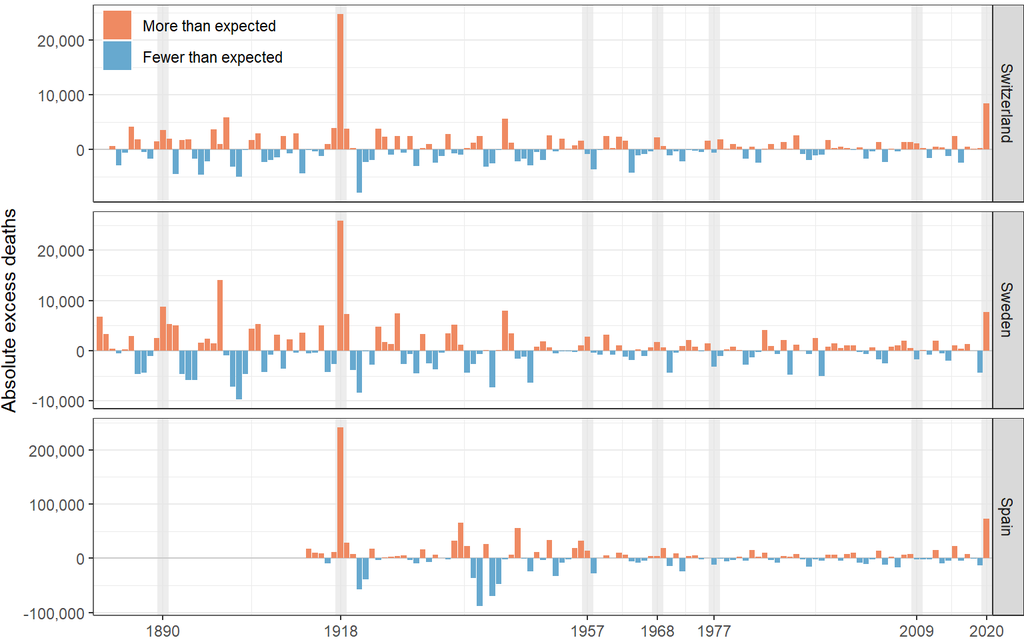

### Percentage

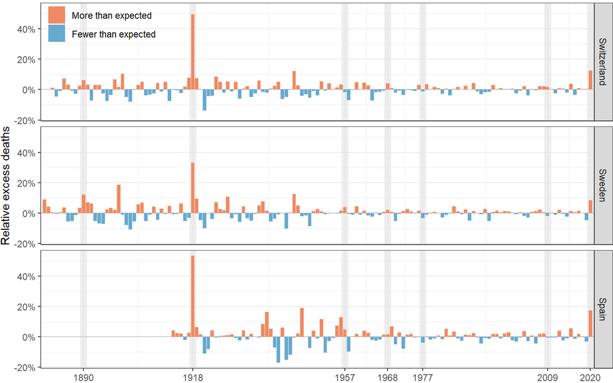

## Figure S2

Monthly estimates of excess

### Absolute

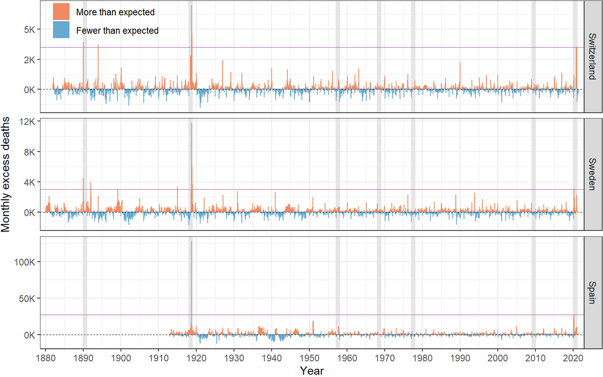

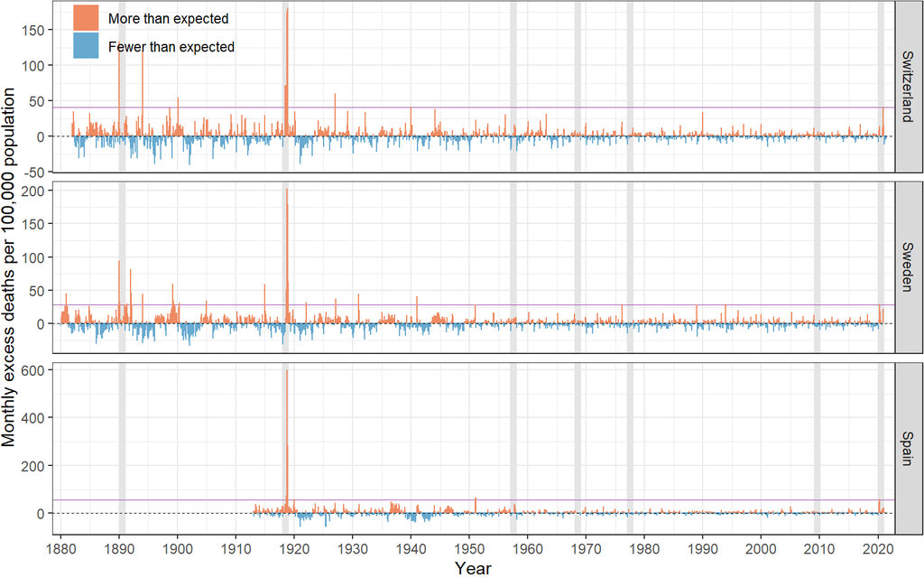

### Percentage

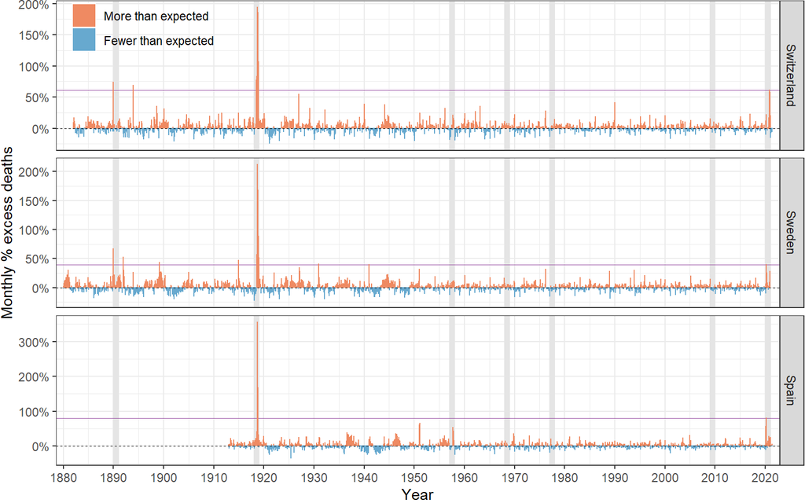

## Figure S3

Zooming to pandemics to explore excess

### Absolute

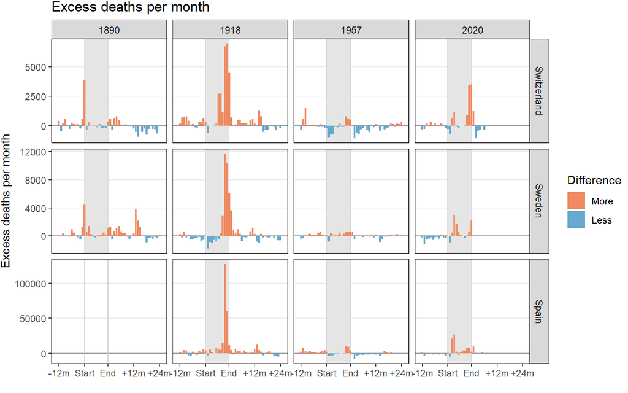

### Percentage

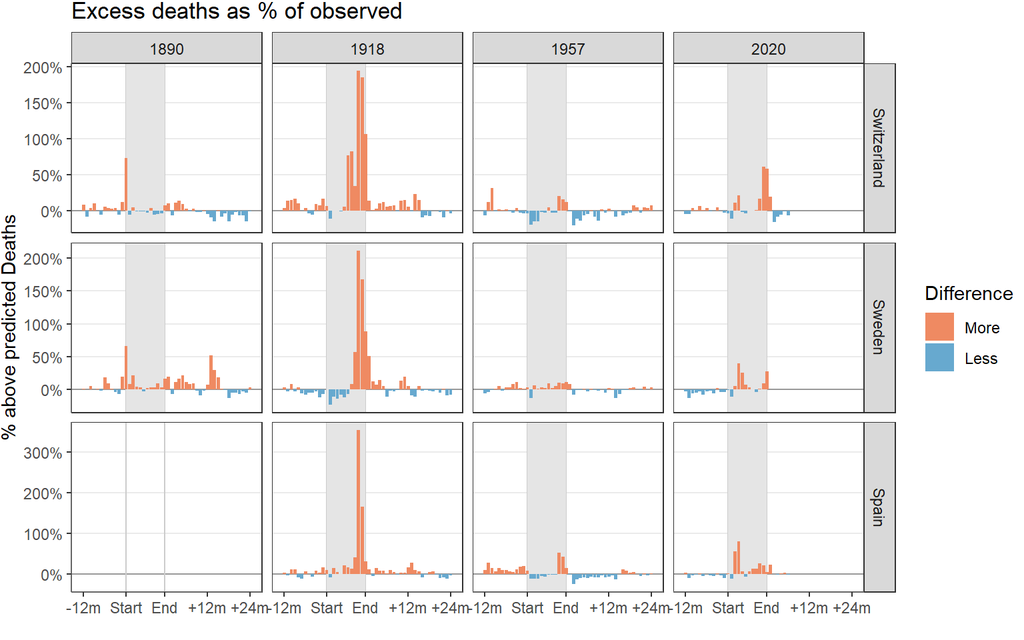

## Figure S4

Age differences across major pandemics - with %s

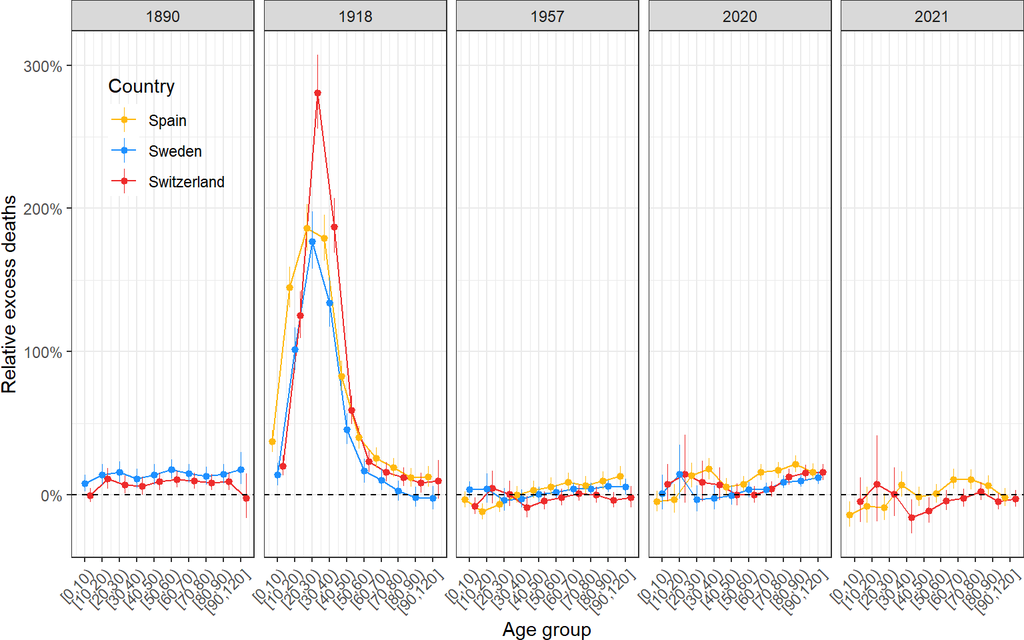

## Figure S5

Different age profiles of excess deaths across two pandemics and three countries.

### Percentage

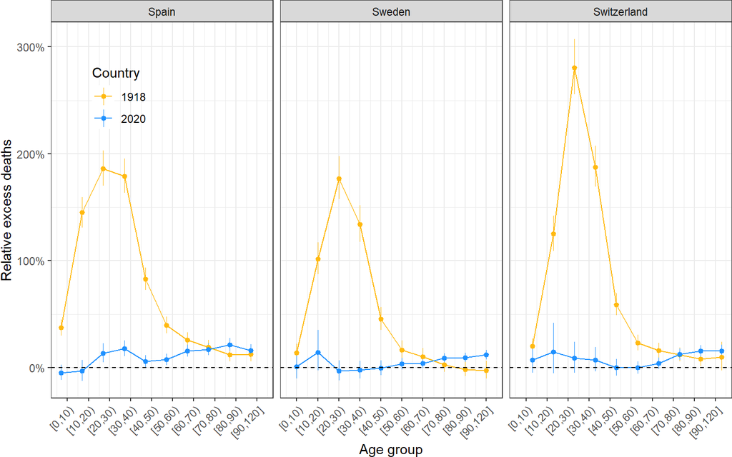

### Per population

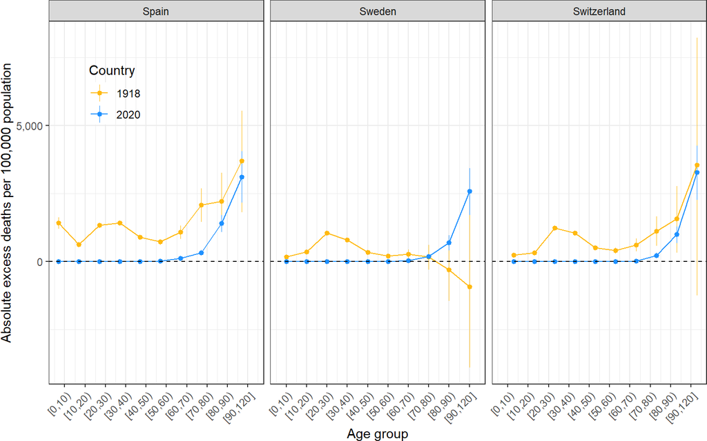

## Figure S6

Impact of extremes: using 1918 pandemic as an example of impact on estimates from 1919 - 1923.  
Estimates with extreme year (blue) and without (red).  
Converge after 5 year smoothing window stops having effect (ie. in 1924).

### Figure 1918-1925

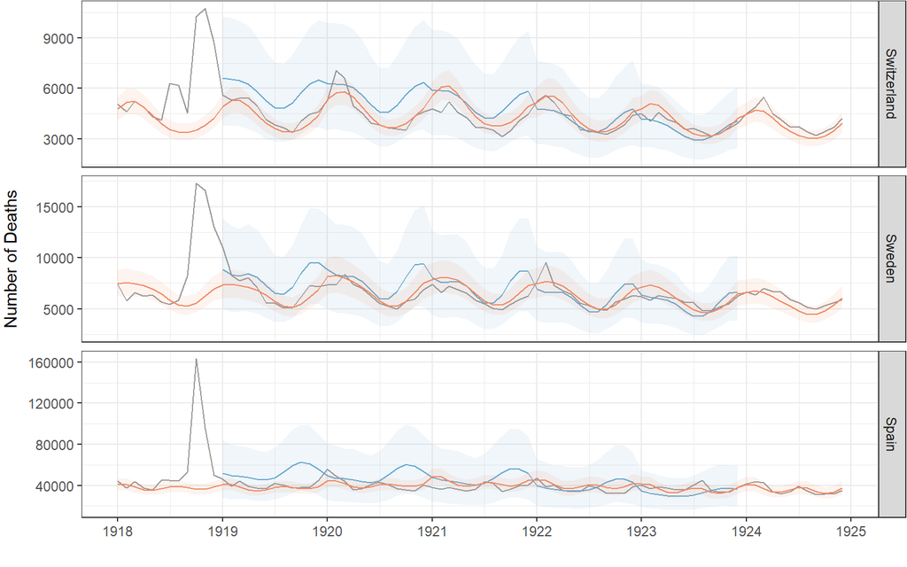

### Table 1919

Using 1918 pandemic as an example of impact on estimates from 1919.

[output not shown]

### Figure 2020-21

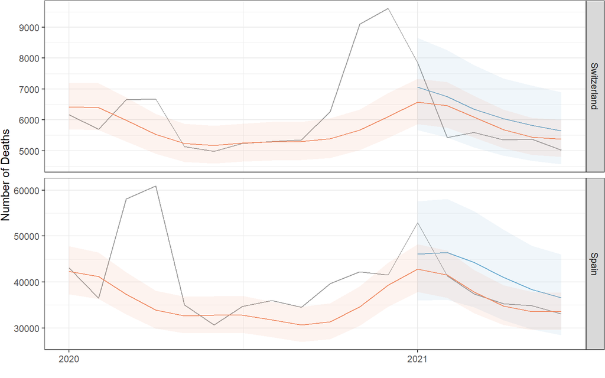

### Table 2021

[output not shown]

## Pandemic compared to last year

**2021 not included yet since not a full year!**

### Absolute

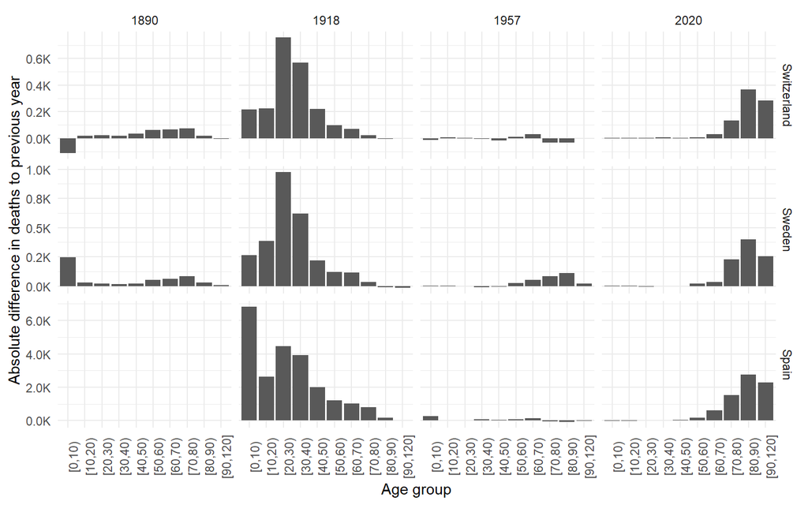

### Relative

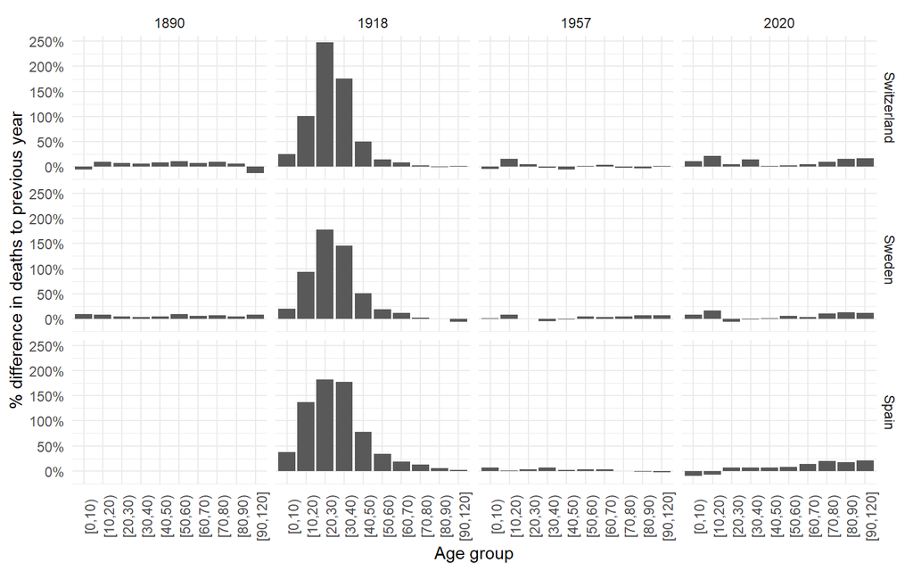

## Comparing to BfS estimates

Data from BfS prepared in `03`. No CI included in comparisons since different age groups are used!

| Year | Excess_BfS | Excess_modelled | Difference |
| --- | --- | --- | --- |
| 2010 | 696 | 264 | -432 |
| 2011 | -672 | -1640 | -968 |
| 2012 | 1436 | 452 | -984 |
| 2013 | 964 | 373 | -591 |
| 2014 | -1528 | -1297 | 231 |
| 2015 | 2463 | 2399 | -64 |
| 2016 | -1994 | -2517 | -523 |
| 2017 | 166 | 494 | 328 |
| 2018 | -76 | 122 | 198 |
| 2019 | 539 | 163 | -376 |
| 2020 | 7950 | 8429 | 479 |
| 2021 | -130 | -1002 | -872 |

# Model diagnostics

## Rhat

Check that all values <1.1

```r
summary(results_month[results_month$Model != "Global Serfling", ]$Rhat)
```

```
   Min. 1st Qu.  Median    Mean 3rd Qu.    Max.
 0.9996  1.0000  1.0002  1.0002  1.0004  1.0017
```

## ESS

Check that all effective sample sizes are large

```r
summary(results_month[results_month$Model != "Global Serfling", ]$n_eff)
```

```
   Min. 1st Qu.  Median    Mean 3rd Qu.    Max.
   4813    6789    7076    7057    7346    8275
```

## Model agreement

Example of 2020

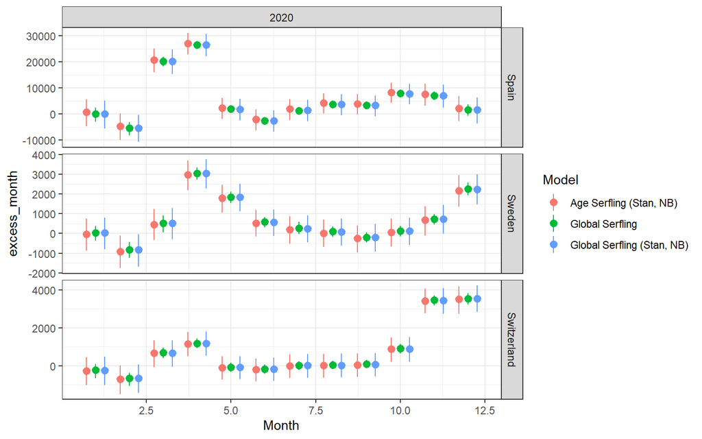

And 1918

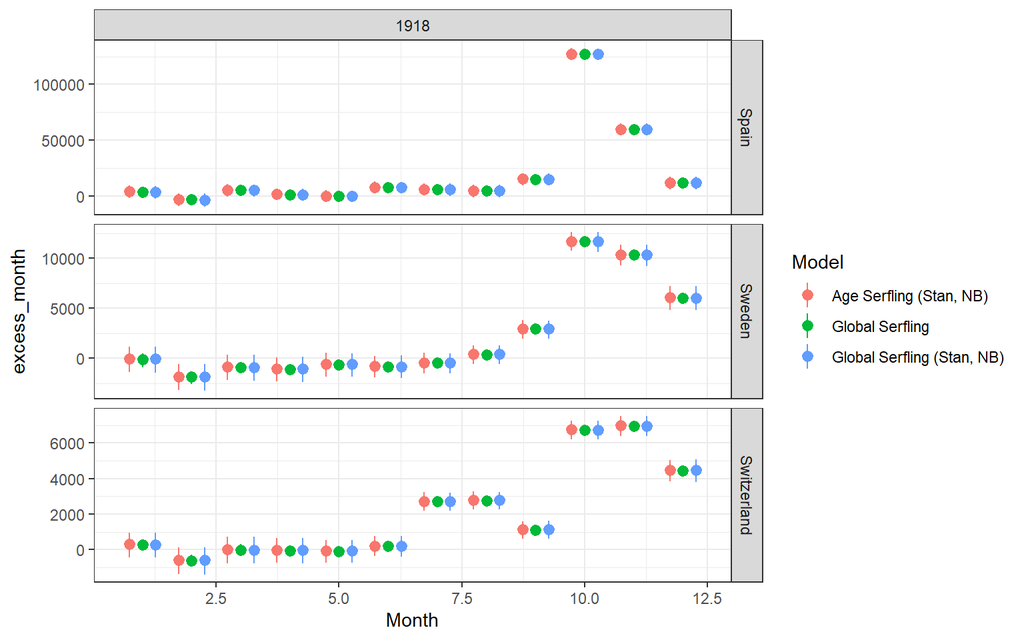

## Check age

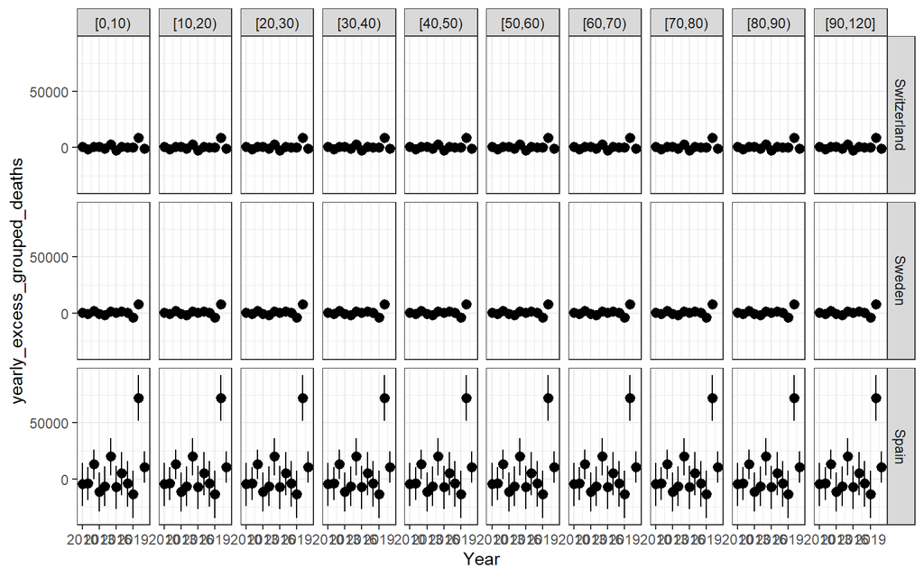

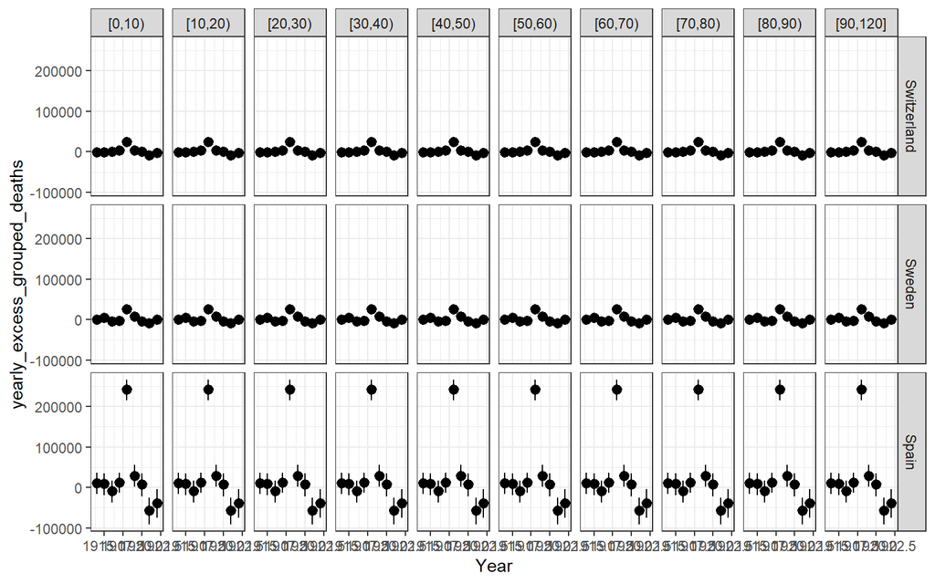

To cite R in publications use:

R Core Team (2021). *R: A Language and Environment for Statistical Computing*. R Foundation for Statistical Computing, Vienna, Austria. https://www.R-project.org/.

To cite the `ggplot2` package in publications use:

Wickham H (2016). *ggplot2: Elegant Graphics for Data Analysis*. Springer-Verlag New York. ISBN 978-3-319-24277-4, https://ggplot2.tidyverse.org.